# Football Win

Tarun Reddy Aleti

March 4th, 2016

### Executive Summary

- The data set at hand covers all the “Serie A” football matches for the last 8 years of Italian Football League.
- Our goal is to predict the final result, having at your disposal the odds of various bookmakers.
- Need to use 6 years of data and predict the result for next 2 years.
- Best model is the one which predicts accurately more often.
- The dataset for the model can be downloaded from [train](https://inclass.kaggle.com/c/football-data-challenge/download/train.csv), [test](https://inclass.kaggle.com/c/football-data-challenge/download/test.csv)

#### Required Packages

Following packages are required for the code to run efficiently.

```r
library(MASS)
library(rjson)
library(plyr)
library(knitr)
library(caret)
library(fmsb)
library(e1071)
library(randomForest)
library(caretEnsemble)
library(ROCR)
library(ineq)
library(zipcode)
library(sqldf)
library(ggplot2)
library(lubridate)
library(psych)
library(caTools)
library(rpart)
library(party)
library(nnet)
```

#### Preliminary Analysis

For the code to execute, all the datasets should be in the R working directory. The datasets are in .csv format.

```r
set.seed(1)
data <- read.csv("train.csv", header = TRUE, stringsAsFactors = FALSE)
final_test <- read.csv("test.csv", header = TRUE, stringsAsFactors = FALSE)
final_test$FTR <- NA
full_data <- rbind(data, final_test)
```

- The data set under consideration has a total of **1520** rows and **21** independent variables. Our dependent variable is *FTR (Full Time Result)* and is a categorical variable, wherein **A** indicates that Away team won, **H** indicates that home team won and **D** indicates that result was a draw
- Independent Variables are as follows
  1. *Date*: Indicates when the match was played
     - Can extract Weekday/Weekend, DayofWeek and Month information
  2. *HomeTeam*: Name of Home Team in the match
     - There are 27 different teams. We might need to create dummy variables for them.
     - The team names are Sampdoria, Verona, Cagliari, Inter, Lazio, Livorno, Napoli, Parma, Torino, Fiorentina, Chievo, Juventus, Atalanta, Bologna, Catania, Genoa, Milan, Roma, Sassuolo, Udinese, Palermo, Lecce, Reggina, Siena, Bari, Cesena, Brescia.
  3. *AwayTeam*: Name of Away Team in the match
     - There are 27 different teams. We might need to create dummy variables for them.
     - The team names are Juventus, Milan, Atalanta, Genoa, Udinese, Roma, Bologna, Chievo, Sassuolo, Catania, Napoli, Lazio, Torino, Sampdoria, Inter, Fiorentina, Cagliari, Verona, Livorno, Parma, Palermo, Siena, Reggina, Lecce, Bari, Cesena, Brescia.
     - There are same number of Home Teams as Away Teams
  4. *B365H*: Bet365 home win odds
  5. *B365D*: Bet365 draw odds
6. *B365A*: Bet365 away win odds
7. *BWH*: Bet&Win home win odds
8. *BWD*: Bet&Win draw odds
9. *BWA*: Bet&Win away win odds
10. *IWH*: Interwetten home win odds
11. *IWD*: Interwetten draw odds
12. *IWA*: Interwetten away win odds
13. *LBH*: Ladbrokes home win odds
14. *LBD*: Ladbrokes draw odds
15. *LBA*: Ladbrokes away win odds
16. *VCH*: VC Bet home win odds
17. *VCD*: VC Bet draw odds
18. *VCA*: VC Bet away win odds
19. *WHH*: William Hill home win odds
20. *WHD*: William Hill draw odds
21. *WHA*: William Hill away win odds

### Exploratory Data Analysis

1. *Frequency of Results*:

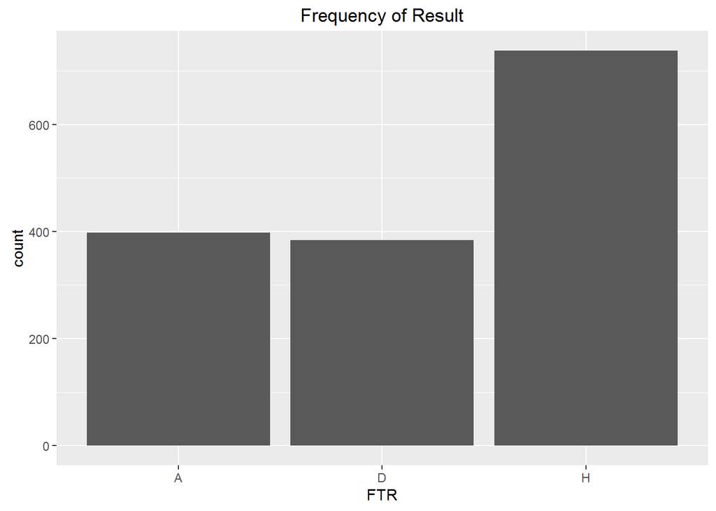

```r
ggplot(data, aes(FTR)) + geom_bar() + ggtitle('Frequency of Result')
```

Home team is more likely to win compare to Away Team or Draw Result. We can use Home Team as our Reference in Analysis

2. Frequency of Games played by Teams at Home:

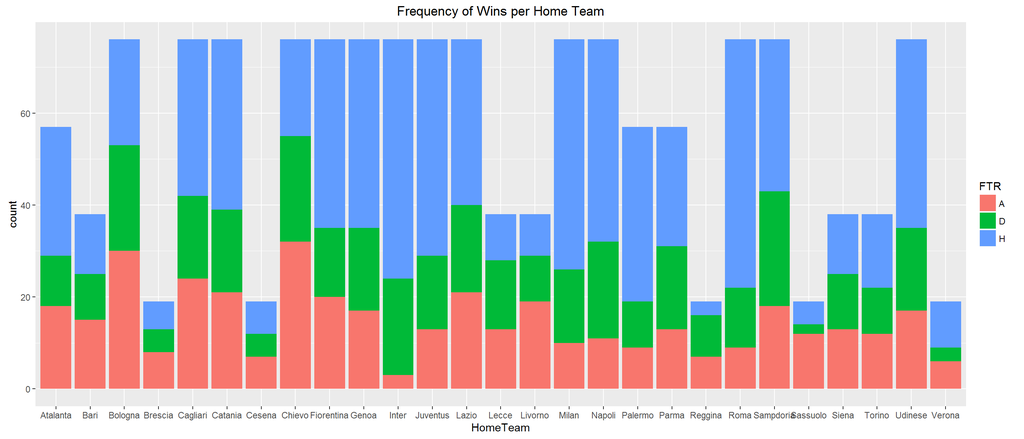

```r
ggplot(data, aes(HomeTeam, fill = FTR)) + geom_bar() + ggtitle('Frequency of Wins per Home Team')
```

3. Frequency of Games played by Teams Away:

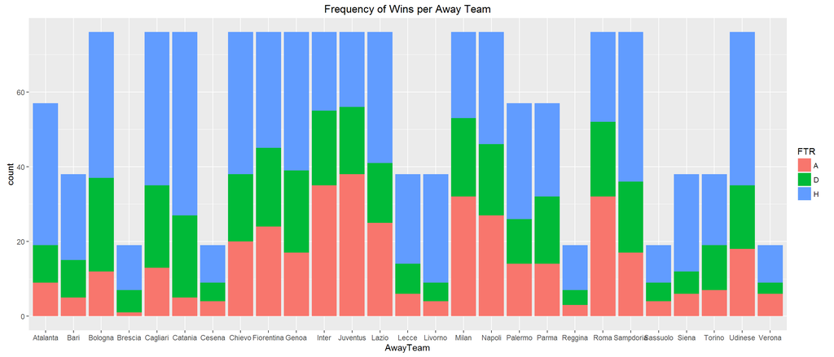

```r
ggplot(data, aes(AwayTeam, fill = FTR)) + geom_bar() + ggtitle('Frequency of Wins per Away Team')
```

4. Average Ratings per Result type for Home Team

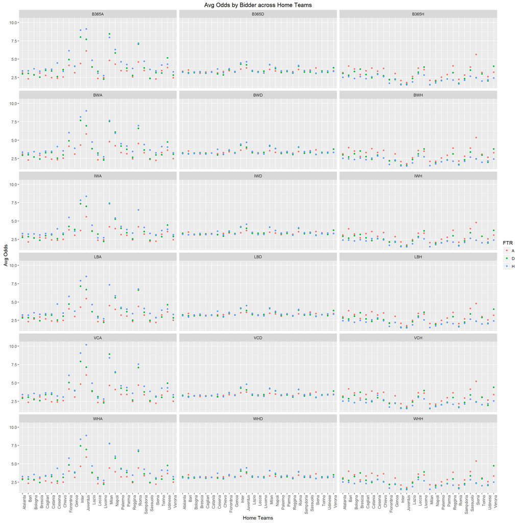

```r
query <- paste("SELECT ", paste('avg(', colnames(data)[6:23], '),', collapse = ""), " HomeTeam, FTR ",
               "FROM data
                GROUP BY HomeTeam, FTR", sep = "")
avg_data <- sqldf(query)
colnames(avg_data) <- c(paste('avg', colnames(data)[6:23], sep = "_"), "HomeTeam", "FTR")
l_avg_data <- alply(avg_data[ ,-c(19, 20)], 2, function(x){
                                                 y <- cbind(x, avg_data[ ,c(19, 20)])
                                                 colnames(y)[1] <- "Avg_Odds"
                                                 return(y)})
n_avg_data <- ldply(l_avg_data, function(x){x})
colnames(n_avg_data)[1] <- "Bid"
n_avg_data[ ,1] <- gsub("avg_", "", n_avg_data[ ,1])
ggplot(n_avg_data, aes(x = HomeTeam, y = Avg_Odds, colour = FTR)) + facet_wrap( ~Bid, nrow = 6, ncol = 3) + geom_point() + theme(axis.text.x = element_text(angle = 90, hjust = 1)) +
xlab('Home Teams') + ylab('Avg Odds') +
ggtitle('Avg Odds by Bidder across Home Teams')
```

Bidding average for home team win are more than draw and draw is slightly more than losing. Also some teams have high average for bid value across compared to other teams and in such cases the bid value of losing is low

5. Average Ratings per Result type for Away Team

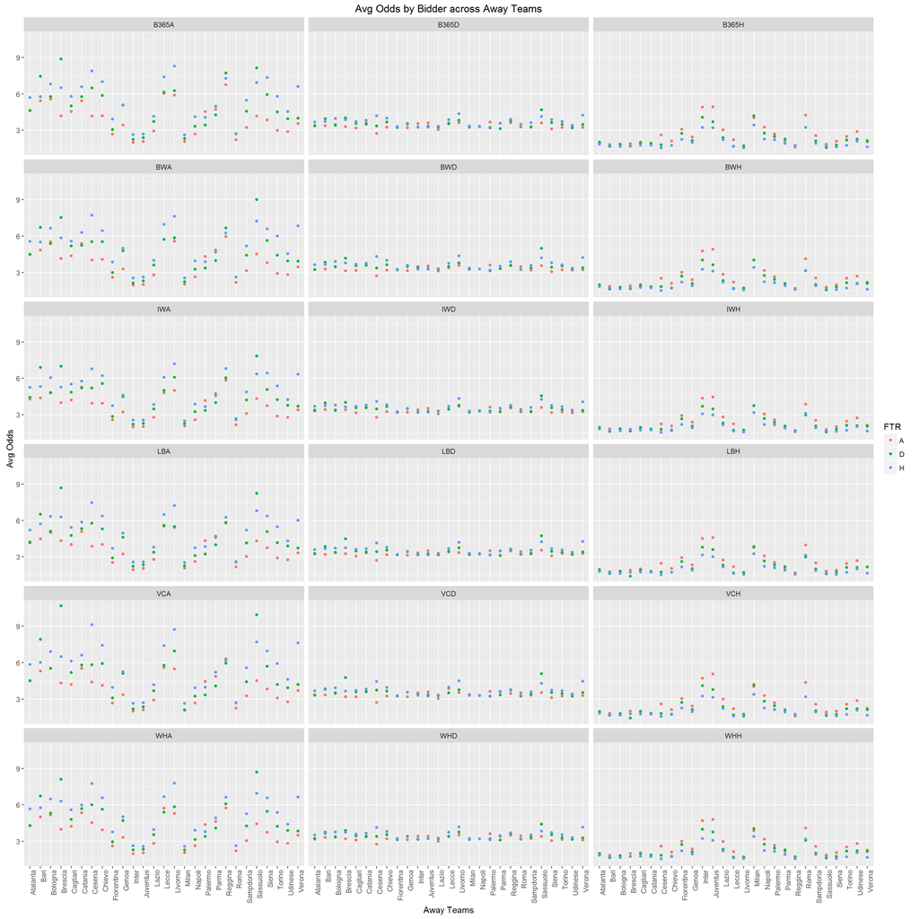

```r
query <- paste("SELECT ", paste('avg(', colnames(data)[6:23], '),', collapse = ""), " AwayTeam, FTR ",
               "FROM data
                GROUP BY AwayTeam, FTR", sep = "")
avg_data <- sqldf(query)
colnames(avg_data) <- c(paste('avg', colnames(data)[6:23], sep = "_"), "AwayTeam", "FTR")
l_avg_data <- alply(avg_data[ ,-c(19, 20)], 2, function(x){
                                                 y <- cbind(x, avg_data[ ,c(19, 20)])
                                                 colnames(y)[1] <- "Avg_Odds"
                                                 return(y)})
n_avg_data <- ldply(l_avg_data, function(x){x})
colnames(n_avg_data)[1] <- "Bid"
n_avg_data[ ,1] <- gsub("avg_", "", n_avg_data[ ,1])
ggplot(n_avg_data, aes(x = AwayTeam, y = Avg_Odds, colour = FTR)) + facet_wrap( ~Bid, nrow = 6, ncol = 3) + geom_point() + theme(axis.text.x = element_text(angle = 90, hjust = 1)) +
xlab('Away Teams') + ylab('Avg Odds') +
ggtitle('Avg Odds by Bidder across Away Teams')
```

This reflects almost mirror results of the above graph away team has low bid value of winning and the teams which have high bid value of winning home have more bid value of winning away game too.

### Dummy Variables

First we need to create dummy variables for all the categorical variables like HomeTeam and AwayTeam

```r
fac_var <- c("HomeTeam", "AwayTeam")

for(var in fac_var){
    full_data[ ,var] <- as.factor(full_data[ ,var])
}

dumm_var <- fac_var

for(dumm in dumm_var){
    dumm_data <- model.matrix( ~ full_data[ ,dumm] - 1, data = full_data)
    colnames(dumm_data) <- paste(dumm, gsub("full_data|, dumm|[[:punct:]]", "", colnames(dumm_data)), sep = "_")
    full_data <- cbind(full_data, dumm_data)
}

colnames(full_data) <- gsub(" ", "", colnames(full_data))
final_data <- full_data[1:dim(data)[1], ]
final_test <- full_data[(dim(data)[1]+1):(dim(data)[1]+dim(final_test)[1]), ]
```

### Missing data - Data Imputation

The bid odds have data missing with 3 for Bet365, 15 for Bet&Win, 16 for InterWetten, 5 for Ladbrokes and 6 for WilliamHill and 19 for VC Bet. We need to impute data for each of them. We simultaneously need to fill the missing data in the test set.

```r
for(bet in colnames(final_data)[6:23]){
  missing_bet <- data[(is.na(final_data[ ,bet])), ]
  missing_test <- final_test[(is.na(final_test[ ,bet])), ]
  if(dim(missing_bet)[1] > 0){
    for(i in 1:dim(missing_bet)[1]){
      x <- data[data$HomeTeam == missing_bet[i, 'HomeTeam'] & data$AwayTeam == missing_bet[i, 'AwayTeam'], ]
      if(dim(x)[1] == 1){
        x <- data[(data$HomeTeam == missing_bet[i, 'HomeTeam'] | data$AwayTeam == missing_bet[i, 'AwayTeam']) & year(data$Date) == year(missing_bet[i, 'Date']), ]
      }
      x$rate <- 1
      x[x[ ,'FTR'] == missing_bet[i, 'FTR'], 'rate'] <- 2
      final_data[which(is.na(data[ ,bet]))[i], bet] <- sum(x$rate * x[ ,bet], na.rm = TRUE)/sum(x$rate, na.rm = TRUE)
    }
  }
  if(dim(missing_test)[1] > 0){
    for(i in 1:dim(missing_test)[1]){
      x <- data[data$HomeTeam == missing_test[i, 'HomeTeam'] & data$AwayTeam == missing_test[i, 'AwayTeam'], ]
      final_test[as.numeric(which(is.na(final_test[ ,bet])))[1], bet] <- mean(x[ ,bet])
    }
  }
}
```

Used other records available for same home team and away team and imputed using weighted mean of the data where data with same result is given twice the weightage compared with other data.

### Near Zero Variance

We need not consider independent variables which do not enough variance in itself. We can use nzv of caret package for this analysis. Following 32 variables have near zero variance and we need not consider them further: HomeTeam_Atalanta, HomeTeam_Bari, HomeTeam_Brescia, HomeTeam_Carpi, HomeTeam_Cesena, HomeTeam_Empoli, HomeTeam_Frosinone, HomeTeam_Lecce, HomeTeam_Livorno, HomeTeam_Palermo, HomeTeam_Parma, HomeTeam_Reggina, HomeTeam_Sassuolo, HomeTeam_Siena, HomeTeam_Torino, HomeTeam_Verona, AwayTeam_Atalanta, AwayTeam_Bari, AwayTeam_Brescia, AwayTeam_Carpi, AwayTeam_Cesena, AwayTeam_Empoli, AwayTeam_Frosinone, AwayTeam_Lecce, AwayTeam_Livorno, AwayTeam_Palermo, AwayTeam_Parma, AwayTeam_Reggina, AwayTeam_Sassuolo, AwayTeam_Siena, AwayTeam_Torino, AwayTeam_Verona

```r
nzv_var <- nzv(final_data)
final_data <- final_data[ ,-nzv_var]
final_test <- final_test[ ,-nzv_var]
```

### Creating Train and Test Samples

- We have a total of **1520** rows and **49** independent variables. Now that we have a clean data set before we head to modeling, we need to create a train and test data sets.

```r
trainIndex <- createDataPartition(final_data$FTR, p = .7, list = FALSE)
train <- final_data[trainIndex, ]
test <- final_data[-trainIndex, ]
```

- Size of train data set is **1065** and test data set is **455**

### Outlier Removal

```r
train <- train[train[ ,'B365H'] < (mean(train[ ,'B365H']) + 2.58 * sd(train[ ,'B365H'])) &
               train[ ,'B365H'] > (mean(train[ ,'B365H']) - 2.58 * sd(train[ ,'B365H'])) &
               train[ ,'B365D'] < (mean(train[ ,'B365D']) + 2.58 * sd(train[ ,'B365D'])) &
               train[ ,'B365D'] > (mean(train[ ,'B365D']) - 2.58 * sd(train[ ,'B365D'])) &
               train[ ,'B365A'] < (mean(train[ ,'B365A']) + 2.58 * sd(train[ ,'B365A'])) &
               train[ ,'B365A'] > (mean(train[ ,'B365A']) - 2.58 * sd(train[ ,'B365A'])) &
               train[ ,'BWH'] < (mean(train[ ,'BWH']) + 2.58 * sd(train[ ,'BWH'])) &
               train[ ,'BWH'] > (mean(train[ ,'BWH']) - 2.58 * sd(train[ ,'BWH'])) &
               train[ ,'BWD'] < (mean(train[ ,'BWD']) + 2.58 * sd(train[ ,'BWD'])) &
               train[ ,'BWD'] > (mean(train[ ,'BWD']) - 2.58 * sd(train[ ,'BWD'])) &
               train[ ,'BWA'] < (mean(train[ ,'BWA']) + 2.58 * sd(train[ ,'BWA'])) &
               train[ ,'BWA'] > (mean(train[ ,'BWA']) - 2.58 * sd(train[ ,'BWA'])) &
               train[ ,'IWH'] < (mean(train[ ,'IWH']) + 2.58 * sd(train[ ,'IWH'])) &
               train[ ,'IWH'] > (mean(train[ ,'IWH']) - 2.58 * sd(train[ ,'IWH'])) &
               train[ ,'IWD'] < (mean(train[ ,'IWD']) + 2.58 * sd(train[ ,'IWD'])) &
               train[ ,'IWD'] > (mean(train[ ,'IWD']) - 2.58 * sd(train[ ,'IWD'])) &
               train[ ,'IWA'] < (mean(train[ ,'IWA']) + 2.58 * sd(train[ ,'IWA'])) &
               train[ ,'IWA'] > (mean(train[ ,'IWA']) - 2.58 * sd(train[ ,'IWA'])) &
               train[ ,'LBH'] < (mean(train[ ,'LBH']) + 2.58 * sd(train[ ,'LBH'])) &
               train[ ,'LBH'] > (mean(train[ ,'LBH']) - 2.58 * sd(train[ ,'LBH'])) &
               train[ ,'LBD'] < (mean(train[ ,'LBD']) + 2.58 * sd(train[ ,'LBD'])) &
               train[ ,'LBD'] > (mean(train[ ,'LBD']) - 2.58 * sd(train[ ,'LBD'])) &
               train[ ,'LBA'] < (mean(train[ ,'LBA']) + 2.58 * sd(train[ ,'LBA'])) &
               train[ ,'LBA'] > (mean(train[ ,'LBA']) - 2.58 * sd(train[ ,'LBA'])) &
               train[ ,'WHH'] < (mean(train[ ,'WHH']) + 2.58 * sd(train[ ,'WHH'])) &
               train[ ,'WHH'] > (mean(train[ ,'WHH']) - 2.58 * sd(train[ ,'WHH'])) &
               train[ ,'WHD'] < (mean(train[ ,'WHD']) + 2.58 * sd(train[ ,'WHD'])) &
               train[ ,'WHD'] > (mean(train[ ,'WHD']) - 2.58 * sd(train[ ,'WHD'])) &
               train[ ,'WHA'] < (mean(train[ ,'WHA']) + 2.58 * sd(train[ ,'WHA'])) &
               train[ ,'WHA'] > (mean(train[ ,'WHA']) - 2.58 * sd(train[ ,'WHA'])) &
               train[ ,'VCH'] < (mean(train[ ,'VCH']) + 2.58 * sd(train[ ,'VCH'])) &
               train[ ,'VCH'] > (mean(train[ ,'VCH']) - 2.58 * sd(train[ ,'VCH'])) &
               train[ ,'VCD'] < (mean(train[ ,'VCD']) + 2.58 * sd(train[ ,'VCD'])) &
               train[ ,'VCD'] > (mean(train[ ,'VCD']) - 2.58 * sd(train[ ,'VCD'])) &
               train[ ,'VCA'] < (mean(train[ ,'VCA']) + 2.58 * sd(train[ ,'VCA'])) &
               train[ ,'VCA'] > (mean(train[ ,'VCA']) - 2.58 * sd(train[ ,'VCA'])), ]
```

- For the continuous independent variables, we have to remove outliers that fall beyond 2.58 times the standard deviation on either side of the mean of that variable (2.58 signifies the two sided 99.5% confidence). *Note: Removed outliers after creating a train and test data sets, inorder to make sure how the performance will be in test set even with presence of outliers*
- The train data set has now **959** rows and **50** columns.

### Correlation

Final check we need to do is correlation among the independent continuous variables. If they have high correlation then we may use Principal Component Analysis or Factor Analysis. There are 46 correlations that have more than 0.8 value, indicating very high correlation in the continuous independent variable. Need to normalize the data before performing factor analysis

```r
train_mean <- apply(train[ ,c(6:23)], 2, mean)
train_sd <- apply(train[ ,c(6:23)], 2, sd)
for(i in 6:23){
  train[ ,i] <- (train[ ,i] - train_mean[i-5])/train_sd[i-5]
  test[ ,i] <- (test[ ,i] - train_mean[i-5])/train_sd[i-5]
  final_test[ ,i] <- (final_test[ ,i] - train_mean[i-5])/train_sd[i-5]
}

fit <- principal(train[ ,c(6:23)], nfactors=18, rotate="varimax")
fit$loadings
```

```
##
## Loadings:
##       PC1    PC2    PC9    PC4    PC5    PC6    PC7    PC8    PC15
## B365H  0.968 -0.204
## B365D -0.197  0.940  0.176                              0.199
## B365A -0.652  0.564  0.483
## BWH    0.973 -0.165 -0.121
## BWD   -0.164  0.952  0.140                      -0.174
## BWA   -0.646  0.590  0.462
## IWH    0.957 -0.188 -0.140
## IWD   -0.207  0.905  0.163  0.334
## IWA   -0.637  0.572  0.472  0.118
## LBH    0.969 -0.170 -0.114
## LBD   -0.186  0.937                       0.284
## LBA   -0.634  0.585  0.478
## WHH    0.970 -0.175 -0.117
## WHD   -0.180  0.925  0.130         0.305
## WHA   -0.624  0.602  0.473
## VCH    0.972 -0.134 -0.144
## VCD   -0.177  0.951                              0.205
## VCA   -0.620  0.653  0.383                                     0.200
##       PC14   PC11   PC10   PC17   PC13   PC12   PC16   PC3    PC18
## B365H                                                  -0.115
## B365D
## B365A                       0.141
## BWH
## BWD
## BWA                                0.137
## IWH          -0.165
## IWD
## IWA   -0.104
## LBH                                      -0.136
## LBD
## LBA                  0.155
## WHH                                             -0.110
## WHD
## WHA    0.149
## VCH
## VCD
## VCA
##
##                  PC1   PC2   PC9   PC4   PC5   PC6   PC7   PC8  PC15  PC14
## SS loadings    8.254 7.554 1.462 0.135 0.105 0.096 0.075 0.052 0.045 0.034
## Proportion Var 0.459 0.420 0.081 0.008 0.006 0.005 0.004 0.003 0.002 0.002
## Cumulative Var 0.459 0.878 0.959 0.967 0.973 0.978 0.982 0.985 0.988 0.990
##                 PC11  PC10  PC17  PC13  PC12  PC16   PC3  PC18
## SS loadings    0.034 0.031 0.030 0.023 0.023 0.018 0.016 0.013
## Proportion Var 0.002 0.002 0.002 0.001 0.001 0.001 0.001 0.001
## Cumulative Var 0.991 0.993 0.995 0.996 0.997 0.998 0.999 1.000
```

```r
train[ ,c('StrongHome', 'StrongDrawWeakAway', 'WeakDrawStrongAway')] <- data.matrix(train[ ,c(6:23)]) %*% data.matrix(fit$loadings[ ,c('PC1', 'PC2', 'PC3')])
test[ ,c('StrongHome', 'StrongDrawWeakAway', 'WeakDrawStrongAway')] <- data.matrix(test[ ,c(6:23)]) %*% data.matrix(fit$loadings[ ,c('PC1', 'PC2', 'PC3')])
final_test[ ,c('StrongHome', 'StrongDrawWeakAway', 'WeakDrawStrongAway')] <- data.matrix(final_test[ ,c(6:23)]) %*% data.matrix(fit$loadings[ ,c('PC1', 'PC2', 'PC3')])
```

### Models

Have attempted many type of models by changing independent variable types, tuning parameters, imputation, partition, etc. Below are the models in that category that yielded best solution.

#### Multinominal Model

```r
logit_model <- multinom(as.formula(paste("FTR ~", paste(colnames(train)[24:54], collapse = " + "), sep = " ")), data = train, trControl = trainControl(method ="cv",number = 15))
train_logit_predict <- fitted(logit_model)
test_logit_predict <- predict(logit_model, newdata = test, "probs")
finaltest_logit_predict <- predict(logit_model, newdata = final_test, "probs")
train$pred_logit_FTR <- apply(train_logit_predict, 1,
                              function(x){
                              return(colnames(train_logit_predict)[which(x == max(x))])
                              })
train_logit_accuracy <- sum(train$FTR == train$pred_logit_FTR)/dim(train)[1]
train_logit_accuracy
```

```
## [1] 0.548488
```

```r
test$pred_logit_FTR <- apply(test_logit_predict, 1,
                             function(x){
                              return(colnames(test_logit_predict)[which(x == max(x))])
                              })
test_logit_accuracy <- sum(test$FTR == test$pred_logit_FTR)/dim(test)[1]
test_logit_accuracy
```

```
## [1] 0.5054945
```

```r
final_test$pred_logit_FTR <- apply(finaltest_logit_predict, 1,
                             function(x){
                              return(colnames(finaltest_logit_predict)[which(x == max(x))])
                              })
```

Tried changing the cross validation number from 5 to 25. After 15 fold the error didn’t change. Used maximum probability approach to find the class prediction from probabilities.

#### Random Forest

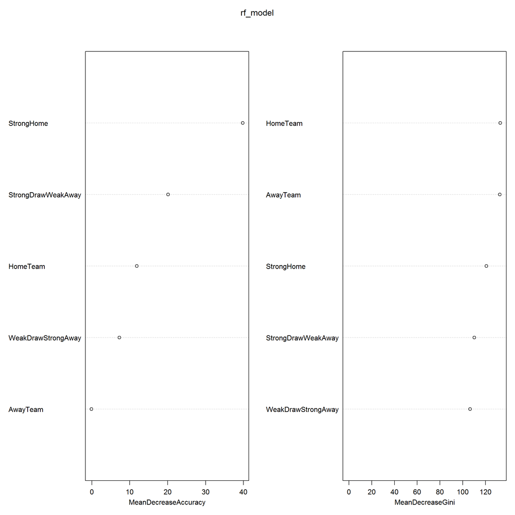

```r
train$FTR <- as.factor(train$FTR)
test$FTR <- as.factor(test$FTR)
rf_model <- randomForest(FTR ~ HomeTeam + AwayTeam + StrongDrawWeakAway + StrongHome + WeakDrawStrongAway,
                         data = train, importance=TRUE, ntree=2000,
                         trControl = trainControl(method ="cv",number = 15))
varImpPlot(rf_model)
```

Tried changing various tuning parameters for randomForest like sample size to be selected across classes, number of trees, cross validation number, formula to train, number of variables to be selected from independent variables. But the above combination yielded best result.

```r
train$pred_rf_FTR <- predict(rf_model, newdata = train)
test$pred_rf_FTR <- predict(rf_model, newdata = test)
final_test$pred_rf_FTR <- predict(rf_model, newdata = final_test)
table(train$FTR, train$pred_rf_FTR)
```

```
##
##       A   D   H
##   A 244   0   0
##   D   0 246   0
##   H   0   0 469
```

```r
table(test$FTR, test$pred_rf_FTR)
```

```
##
##       A   D   H
##   A  50  10  59
##   D  27  10  78
##   H  36  20 165
```

```r
train_rf_accuracy <- sum(train$FTR == train$pred_rf_FTR)/dim(train)[1]
train_rf_accuracy
```

```
## [1] 1
```

```r
test_rf_accuracy <- sum(test$FTR == test$pred_rf_FTR)/dim(test)[1]
test_rf_accuracy
```

```
## [1] 0.4945055
```

We see that random forest fits perfectly for train data but for test data the accuracy decreases by half. Its not able to predict the class “D”. Even changing the sample size doesn’t help it further decreases the overall accuracy.

#### Naive Bayes

```r
nb_model <- naiveBayes(FTR ~ HomeTeam + AwayTeam + StrongDrawWeakAway + StrongHome + WeakDrawStrongAway,
                         data = train)
train$pred_nb_FTR <- predict(nb_model, newdata = train)
test$pred_nb_FTR <- predict(nb_model, newdata = test)
final_test$pred_nb_FTR <- predict(nb_model, newdata = final_test)
table(test$FTR, test$pred_nb_FTR)
```

```
##
##       A   D   H
##   A  69   8  42
##   D  46   6  63
##   H  61   7 153
```

```r
train_nb_accuracy <- sum(train$FTR == train$pred_nb_FTR)/dim(train)[1]
train_nb_accuracy
```

```
## [1] 0.5328467
```

```r
test_nb_accuracy <- sum(test$FTR == test$pred_nb_FTR)/dim(test)[1]
test_nb_accuracy
```

```
## [1] 0.5010989
```

Again model is not able to predict the class “D”

#### CART Model

```r
ct_model <- rpart(as.formula(paste("FTR ~",paste(colnames(train)[24:54], collapse = " + "),
                                       sep = " ")),
                  method = "class", data = train)
printcp(ct_model)
```

```
##
## Classification tree:
## rpart(formula = as.formula(paste("FTR ~", paste(colnames(train)[24:54],
##     collapse = " + "), sep = " ")), data = train, method = "class")
##
## Variables actually used in tree construction:
## [1] StrongHome
##
## Root node error: 490/959 = 0.51095
##
## n= 959
##
##        CP nsplit rel error  xerror     xstd
## 1 0.10408      0   1.00000 1.00000 0.031592
## 2 0.01000      1   0.89592 0.93469 0.031568
```

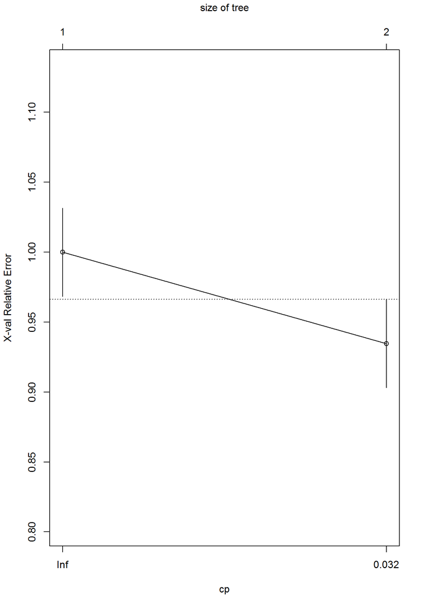

```r
plotcp(ct_model)
```

```r
summary(ct_model)
```

```
## Call:
## rpart(formula = as.formula(paste("FTR ~", paste(colnames(train)[24:54],
##     collapse = " + "), sep = " ")), data = train, method = "class")
##   n= 959
##
##          CP nsplit rel error    xerror       xstd
## 1 0.1040816      0 1.0000000 1.0000000 0.03159214
## 2 0.0100000      1 0.8959184 0.9346939 0.03156794
##
## Variable importance
##         StrongHome StrongDrawWeakAway WeakDrawStrongAway
##                 52                 18                 16
##     AwayTeam_Milan  AwayTeam_Juventus     AwayTeam_Inter
##                  6                  4                  4
##
## Node number 1: 959 observations,    complexity param=0.1040816
##   predicted class=H  expected loss=0.5109489  P(node) =1
##     class counts:   244   246   469
##    probabilities: 0.254 0.257 0.489
##   left son=2 (222 obs) right son=3 (737 obs)
##   Primary splits:
##       StrongHome         < 6.355035    to the right, improve=32.031790, (0 missing)
##       StrongDrawWeakAway < -3.764988   to the left,  improve=25.828350, (0 missing)
##       WeakDrawStrongAway < -0.02238395 to the left,  improve=12.275090, (0 missing)
##       HomeTeam_Inter     < 0.5         to the left,  improve= 4.388166, (0 missing)
##       HomeTeam_Roma      < 0.5         to the left,  improve= 3.968209, (0 missing)
##   Surrogate splits:
##       StrongDrawWeakAway < -6.492406   to the left,  agree=0.849, adj=0.347, (0 split)
##       WeakDrawStrongAway < -0.01769164 to the left,  agree=0.839, adj=0.306, (0 split)
##       AwayTeam_Milan     < 0.5         to the right, agree=0.797, adj=0.122, (0 split)
##       AwayTeam_Juventus  < 0.5         to the right, agree=0.788, adj=0.086, (0 split)
##       AwayTeam_Inter     < 0.5         to the right, agree=0.787, adj=0.081, (0 split)
##
## Node number 2: 222 observations
##   predicted class=A  expected loss=0.536036  P(node) =0.2314911
##     class counts:   103    67    52
##    probabilities: 0.464 0.302 0.234
##
## Node number 3: 737 observations
##   predicted class=H  expected loss=0.4341927  P(node) =0.7685089
##     class counts:   141   179   417
##    probabilities: 0.191 0.243 0.566
```

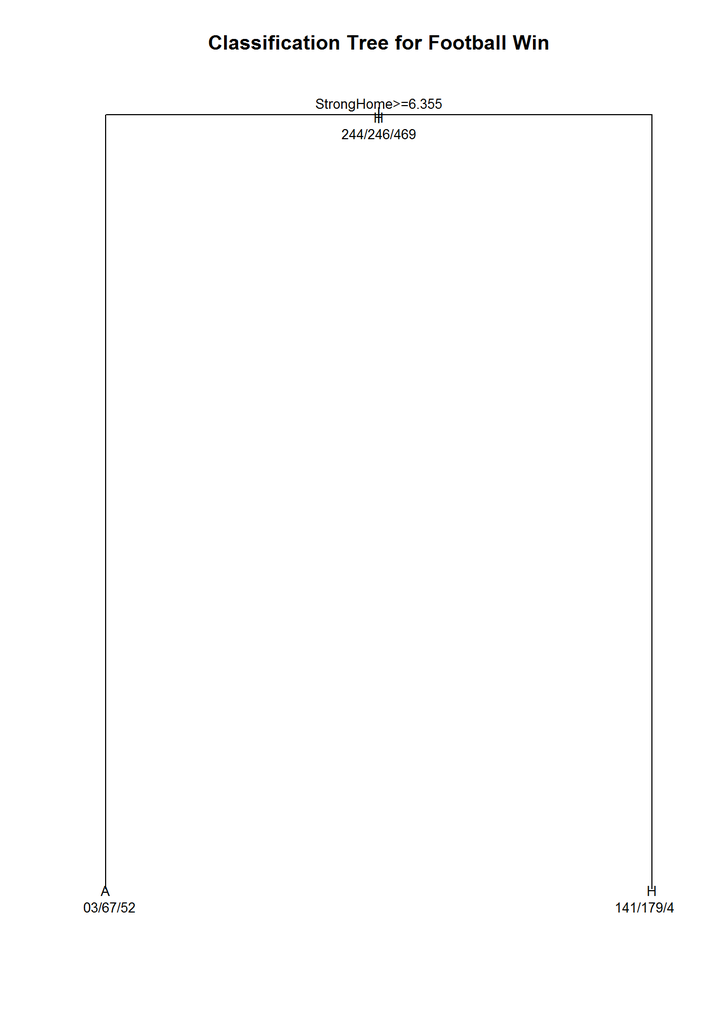

```r
plot(ct_model, uniform=TRUE,
     main="Classification Tree for Football Win")
text(ct_model, use.n=TRUE, all=TRUE, cex=.8)
```

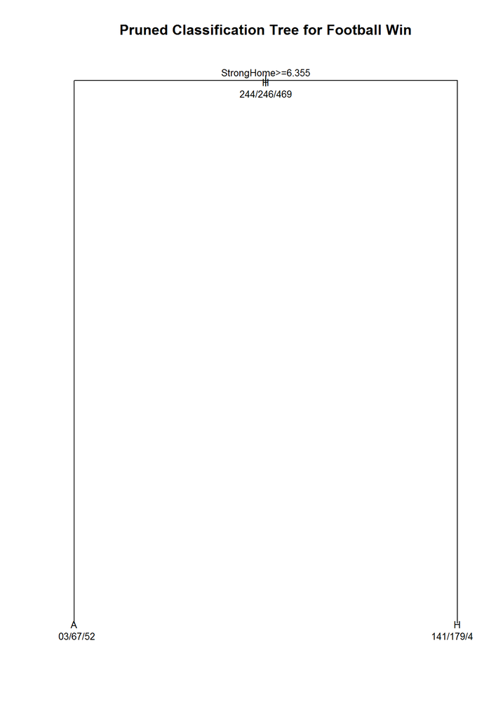

```r
# prune the tree
pct_model <- prune(ct_model, cp=ct_model$cptable[which.min(ct_model$cptable[,"xerror"]),"CP"])

# plot the pruned tree
plot(pct_model, uniform=TRUE,
    main="Pruned Classification Tree for Football Win")
text(pct_model, use.n=TRUE, all=TRUE, cex=.8)
```

```r
train_ct_predict <- predict(pct_model, newdata = train)
test_ct_predict <- predict(pct_model, newdata = test)
finaltest_ct_predict <- predict(pct_model, newdata = final_test)
train$pred_ct_FTR <- apply(train_ct_predict, 1,
                              function(x){
                              return(colnames(train_ct_predict)[which(x == max(x))])
                              })
table(train$FTR, train$pred_ct_FTR)
```

```
##
##       A   H
##   A 103 141
##   D  67 179
##   H  52 417
```

```r
train_ct_accuracy <- sum(train$FTR == train$pred_ct_FTR)/dim(train)[1]
train_ct_accuracy
```

```
## [1] 0.5422315
```

```r
test$pred_ct_FTR <- apply(test_ct_predict, 1,
                             function(x){
                              return(colnames(test_ct_predict)[which(x == max(x))])
                              })
table(test$FTR, test$pred_ct_FTR)
```

```
##
##       A   H
##   A  56  63
##   D  28  87
##   H  35 186
```

```r
test_ct_accuracy <- sum(test$FTR == test$pred_ct_FTR)/dim(test)[1]
test_ct_accuracy
```

```
## [1] 0.5318681
```

Using pruning method doesn’t help much. Used same method as we used for logistic to convert probabilities to category predictions. Model still faces the bias in terms of not being able to predict the class D. Kaggle score was also pretty bad.

#### Conditional Inference Tree

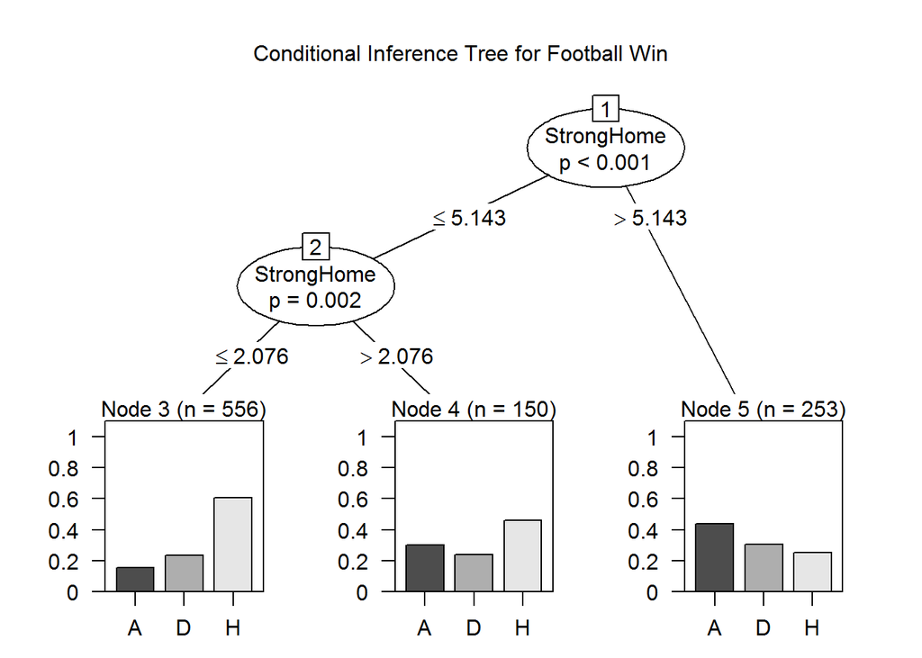

```r
cit_model <- ctree(as.formula(paste("FTR ~",paste(colnames(train)[24:54], collapse = " + "),
                                       sep = " ")),
                   data = train)
plot(cit_model, main="Conditional Inference Tree for Football Win")
```

```r
train$pred_cit_FTR <- predict(cit_model, newdata = train)
test$pred_cit_FTR <- predict(cit_model, newdata = test)
final_test$pred_cit_FTR <- predict(cit_model, newdata = final_test)
table(train$FTR, train$pred_cit_FTR)
```

```
##
##       A   D   H
##   A 111   0 133
##   D  78   0 168
##   H  64   0 405
```

```r
train_cit_accuracy <- sum(train$FTR == train$pred_cit_FTR)/dim(train)[1]
train_cit_accuracy
```

```
## [1] 0.5380605
```

```r
table(test$FTR, test$pred_cit_FTR)
```

```
##
##       A   D   H
##   A  59   0  60
##   D  30   0  85
##   H  41   0 180
```

```r
test_cit_accuracy <- sum(test$FTR == test$pred_cit_FTR)/dim(test)[1]
test_cit_accuracy
```

```
## [1] 0.5252747
```

Performance is not much different from CART model.

#### Ensemble Approach

Tried all different models, different combinations from above in the tuneList. Most of them had high correlation with other models. Also models like NaiveBayes, CART and Conditional Inference Tree were performing poorly in predicting class D. Tried ensemble model of multinominal and random forest and it gave the best kaggle score.

```r
en_model <- caretList(as.formula(paste("FTR ~", paste(colnames(train)[24:54], collapse = " + "),
                                       sep = " ")),
                      data = train,
                            tuneList=list(
                                                rf1 = caretModelSpec(method = "rf", ntrees = 2000)),
                            trControl = trainControl(method ="cv",number = 15))

alltrain_model_preds <- lapply(en_model, predict, newdata=train, type='prob')
train_model_preds <- train_logit_predict
alltest_model_preds <- lapply(en_model, predict, newdata=test, type='prob')
test_model_preds <- test_logit_predict
allfinaltest_model_preds <- lapply(en_model, predict, newdata=final_test, type='prob')
finaltest_model_preds <- finaltest_logit_predict
for(model in rownames(summary(en_model))){
  train_model_preds <- cbind(train_model_preds, alltrain_model_preds[[model]])
  test_model_preds <- cbind(test_model_preds, alltest_model_preds[[model]])
  finaltest_model_preds <- cbind(finaltest_model_preds, allfinaltest_model_preds[[model]])
}
train$pred_en_FTR <- apply(train_model_preds, 1,
                              function(x){
                                z <- NULL
                                j <- 0
                                total_class <- length(unique(colnames(train_model_preds)))
                                total_model <- length(rownames(summary(en_model)))
                                  for(i in 1:total_class){
                                    z <- c(z, mean(x[seq(i+j, i+(total_class * total_model)+j, total_class)]))
                                    j
                                  }
                                return(colnames(train_model_preds)[which(z == max(z))])
                              })
test$pred_en_FTR <- apply(test_model_preds, 1,
                              function(x){
                                z <- NULL
                                j <- 0
                                total_class <- length(unique(colnames(train_model_preds)))
                                total_model <- length(rownames(summary(en_model)))
                                  for(i in 1:total_class){
                                    z <- c(z, mean(x[seq(i+j, i+(total_class * total_model)+j, total_class)]))
                                    j
                                  }
                                return(colnames(train_model_preds)[which(z == max(z))])
                              })
final_test$pred_en_FTR <- apply(finaltest_model_preds, 1,
                                function(x){
                                z <- NULL
                                j <- 0
                                total_class <- length(unique(colnames(train_model_preds)))
                                total_model <- length(rownames(summary(en_model)))
                                  for(i in 1:total_class){
                                    z <- c(z, mean(x[seq(i+j, i+(total_class * total_model)+j, total_class)]))
                                    j
                                  }
                                return(colnames(train_model_preds)[which(z == max(z))])
                              })

table(train$FTR, train$pred_en_FTR)
```

```
##
##       A   D   H
##   A 109   0 135
##   D  54   8 184
##   H  34   2 433
```

```r
train_en_accuracy <- sum(train$FTR == train$pred_en_FTR)/dim(train)[1]
train_en_accuracy
```

```
## [1] 0.5735141
```

```r
table(test$FTR, test$pred_en_FTR)
```

```
##
##       A   D   H
##   A  51   0  68
##   D  28   1  86
##   H  35   1 185
```

```r
test_en_accuracy <- sum(test$FTR == test$pred_en_FTR)/dim(test)[1]
test_en_accuracy
```

```
## [1] 0.5208791
```

### Conclusions

1. Ensemble Model of Multinominal and Random Forest gave best kaggle score.
2. Attempted various models, tuning parameters, independent variables (weekday, month, daytype) but all of them were making the model worse.
3. One approach that could be explored is trying two differnet models one that predicts Home win or not and then if it doesn’t it predicts if its Away win or Draw win. This way we may increase chances of predicting class D.